# Risk Factor Analysis

## Outcome Variable

**Outcome Variable:** pers_wast

## Predictor Variables

**Intervention Variable:** meducyrs

**Adjustment Set:**

- arm
- W_mage
- feducyrs
- W_mhtcm
- W_mwtkg
- W_mbmi
- W_gagebrth
- W_birthwt
- W_birthlen
- single
- delta_W_mage
- delta_feducyrs
- delta_W_mhtcm
- delta_W_mwtkg
- delta_W_mbmi
- delta_W_gagebrth
- delta_W_birthwt
- delta_W_birthlen
- delta_single

## Stratifying Variables

The analysis was stratified on these variable(s):

- agecat
- studyid
- country

## Data Summary

| agecat | studyid | country | meducyrs | pers_wast | n_cell | n |
| --- | --- | --- | --- | --- | --- | --- |
| 0-24 months | ki0047075b-MAL-ED | BANGLADESH | High | 0 | 71 | 202 |
| 0-24 months | ki0047075b-MAL-ED | BANGLADESH | High | 1 | 4 | 202 |
| 0-24 months | ki0047075b-MAL-ED | BANGLADESH | Low | 0 | 62 | 202 |
| 0-24 months | ki0047075b-MAL-ED | BANGLADESH | Low | 1 | 4 | 202 |
| 0-24 months | ki0047075b-MAL-ED | BANGLADESH | Medium | 0 | 59 | 202 |
| 0-24 months | ki0047075b-MAL-ED | BANGLADESH | Medium | 1 | 2 | 202 |
| 0-24 months | ki0047075b-MAL-ED | BRAZIL | High | 0 | 74 | 217 |
| 0-24 months | ki0047075b-MAL-ED | BRAZIL | High | 1 | 0 | 217 |
| 0-24 months | ki0047075b-MAL-ED | BRAZIL | Low | 0 | 59 | 217 |
| 0-24 months | ki0047075b-MAL-ED | BRAZIL | Low | 1 | 1 | 217 |
| 0-24 months | ki0047075b-MAL-ED | BRAZIL | Medium | 0 | 82 | 217 |
| 0-24 months | ki0047075b-MAL-ED | BRAZIL | Medium | 1 | 1 | 217 |
| 0-24 months | ki0047075b-MAL-ED | INDIA | High | 0 | 56 | 210 |
| 0-24 months | ki0047075b-MAL-ED | INDIA | High | 1 | 4 | 210 |
| 0-24 months | ki0047075b-MAL-ED | INDIA | Low | 0 | 63 | 210 |
| 0-24 months | ki0047075b-MAL-ED | INDIA | Low | 1 | 10 | 210 |
| 0-24 months | ki0047075b-MAL-ED | INDIA | Medium | 0 | 72 | 210 |
| 0-24 months | ki0047075b-MAL-ED | INDIA | Medium | 1 | 5 | 210 |
| 0-24 months | ki0047075b-MAL-ED | NEPAL | High | 0 | 53 | 223 |
| 0-24 months | ki0047075b-MAL-ED | NEPAL | High | 1 | 0 | 223 |
| 0-24 months | ki0047075b-MAL-ED | NEPAL | Low | 0 | 93 | 223 |
| 0-24 months | ki0047075b-MAL-ED | NEPAL | Low | 1 | 1 | 223 |
| 0-24 months | ki0047075b-MAL-ED | NEPAL | Medium | 0 | 74 | 223 |
| 0-24 months | ki0047075b-MAL-ED | NEPAL | Medium | 1 | 2 | 223 |
| 0-24 months | ki0047075b-MAL-ED | PERU | High | 0 | 85 | 283 |
| 0-24 months | ki0047075b-MAL-ED | PERU | High | 1 | 0 | 283 |
| 0-24 months | ki0047075b-MAL-ED | PERU | Low | 0 | 98 | 283 |
| 0-24 months | ki0047075b-MAL-ED | PERU | Low | 1 | 0 | 283 |
| 0-24 months | ki0047075b-MAL-ED | PERU | Medium | 0 | 99 | 283 |
| 0-24 months | ki0047075b-MAL-ED | PERU | Medium | 1 | 1 | 283 |

[output cut: 396 more lines]

The following strata were considered:

- agecat: 0-24 months, studyid: ki0047075b-MAL-ED, country: BANGLADESH
- agecat: 0-24 months, studyid: ki0047075b-MAL-ED, country: BRAZIL
- agecat: 0-24 months, studyid: ki0047075b-MAL-ED, country: INDIA
- agecat: 0-24 months, studyid: ki0047075b-MAL-ED, country: NEPAL
- agecat: 0-24 months, studyid: ki0047075b-MAL-ED, country: PERU
- agecat: 0-24 months, studyid: ki0047075b-MAL-ED, country: SOUTH AFRICA
- agecat: 0-24 months, studyid: ki0047075b-MAL-ED, country: TANZANIA, UNITED REPUBLIC OF
- agecat: 0-24 months, studyid: ki1000108-CMC-V-BCS-2002, country: INDIA
- agecat: 0-24 months, studyid: ki1000108-IRC, country: INDIA
- agecat: 0-24 months, studyid: ki1000109-EE, country: PAKISTAN
- agecat: 0-24 months, studyid: ki1000304b-SAS-CompFeed, country: INDIA
- agecat: 0-24 months, studyid: ki1000304b-SAS-FoodSuppl, country: INDIA
- agecat: 0-24 months, studyid: ki1017093-NIH-Birth, country: BANGLADESH
- agecat: 0-24 months, studyid: ki1017093b-PROVIDE, country: BANGLADESH
- agecat: 0-24 months, studyid: ki1017093c-NIH-Crypto, country: BANGLADESH
- agecat: 0-24 months, studyid: ki1066203-TanzaniaChild2, country: TANZANIA, UNITED REPUBLIC OF
- agecat: 0-24 months, studyid: ki1112895-Guatemala BSC, country: GUATEMALA
- agecat: 0-24 months, studyid: ki1113344-GMS-Nepal, country: NEPAL
- agecat: 0-24 months, studyid: ki1119695-PROBIT, country: BELARUS
- agecat: 0-24 months, studyid: ki1126311-ZVITAMBO, country: ZIMBABWE
- agecat: 0-24 months, studyid: ki1135781-COHORTS, country: GUATEMALA
- agecat: 0-24 months, studyid: ki1135781-COHORTS, country: INDIA
- agecat: 0-24 months, studyid: ki1135781-COHORTS, country: PHILIPPINES
- agecat: 0-24 months, studyid: ki1148112-LCNI-5, country: MALAWI
- agecat: 0-24 months, studyid: kiGH5241-JiVitA-3, country: BANGLADESH
- agecat: 0-24 months, studyid: kiGH5241-JiVitA-4, country: BANGLADESH
- agecat: 0-6 months, studyid: ki0047075b-MAL-ED, country: BANGLADESH
- agecat: 0-6 months, studyid: ki0047075b-MAL-ED, country: BRAZIL
- agecat: 0-6 months, studyid: ki0047075b-MAL-ED, country: INDIA
- agecat: 0-6 months, studyid: ki0047075b-MAL-ED, country: NEPAL
- agecat: 0-6 months, studyid: ki0047075b-MAL-ED, country: PERU
- agecat: 0-6 months, studyid: ki0047075b-MAL-ED, country: SOUTH AFRICA
- agecat: 0-6 months, studyid: ki0047075b-MAL-ED, country: TANZANIA, UNITED REPUBLIC OF
- agecat: 0-6 months, studyid: ki1000108-CMC-V-BCS-2002, country: INDIA
- agecat: 0-6 months, studyid: ki1000108-IRC, country: INDIA
- agecat: 0-6 months, studyid: ki1000109-EE, country: PAKISTAN
- agecat: 0-6 months, studyid: ki1017093-NIH-Birth, country: BANGLADESH
- agecat: 0-6 months, studyid: ki1017093b-PROVIDE, country: BANGLADESH
- agecat: 0-6 months, studyid: ki1017093c-NIH-Crypto, country: BANGLADESH
- agecat: 0-6 months, studyid: ki1066203-TanzaniaChild2, country: TANZANIA, UNITED REPUBLIC OF
- agecat: 0-6 months, studyid: ki1113344-GMS-Nepal, country: NEPAL
- agecat: 0-6 months, studyid: ki1119695-PROBIT, country: BELARUS
- agecat: 0-6 months, studyid: ki1126311-ZVITAMBO, country: ZIMBABWE
- agecat: 0-6 months, studyid: ki1135781-COHORTS, country: PHILIPPINES
- agecat: 0-6 months, studyid: kiGH5241-JiVitA-3, country: BANGLADESH
- agecat: 6-24 months, studyid: ki0047075b-MAL-ED, country: BANGLADESH
- agecat: 6-24 months, studyid: ki0047075b-MAL-ED, country: BRAZIL
- agecat: 6-24 months, studyid: ki0047075b-MAL-ED, country: INDIA
- agecat: 6-24 months, studyid: ki0047075b-MAL-ED, country: NEPAL
- agecat: 6-24 months, studyid: ki0047075b-MAL-ED, country: PERU
- agecat: 6-24 months, studyid: ki0047075b-MAL-ED, country: SOUTH AFRICA
- agecat: 6-24 months, studyid: ki0047075b-MAL-ED, country: TANZANIA, UNITED REPUBLIC OF
- agecat: 6-24 months, studyid: ki1000108-CMC-V-BCS-2002, country: INDIA
- agecat: 6-24 months, studyid: ki1000108-IRC, country: INDIA
- agecat: 6-24 months, studyid: ki1000109-EE, country: PAKISTAN
- agecat: 6-24 months, studyid: ki1000304b-SAS-CompFeed, country: INDIA
- agecat: 6-24 months, studyid: ki1000304b-SAS-FoodSuppl, country: INDIA
- agecat: 6-24 months, studyid: ki1017093-NIH-Birth, country: BANGLADESH
- agecat: 6-24 months, studyid: ki1017093b-PROVIDE, country: BANGLADESH
- agecat: 6-24 months, studyid: ki1017093c-NIH-Crypto, country: BANGLADESH
- agecat: 6-24 months, studyid: ki1066203-TanzaniaChild2, country: TANZANIA, UNITED REPUBLIC OF
- agecat: 6-24 months, studyid: ki1112895-Guatemala BSC, country: GUATEMALA
- agecat: 6-24 months, studyid: ki1113344-GMS-Nepal, country: NEPAL
- agecat: 6-24 months, studyid: ki1119695-PROBIT, country: BELARUS
- agecat: 6-24 months, studyid: ki1126311-ZVITAMBO, country: ZIMBABWE
- agecat: 6-24 months, studyid: ki1135781-COHORTS, country: GUATEMALA
- agecat: 6-24 months, studyid: ki1135781-COHORTS, country: INDIA
- agecat: 6-24 months, studyid: ki1135781-COHORTS, country: PHILIPPINES
- agecat: 6-24 months, studyid: ki1148112-LCNI-5, country: MALAWI
- agecat: 6-24 months, studyid: kiGH5241-JiVitA-3, country: BANGLADESH
- agecat: 6-24 months, studyid: kiGH5241-JiVitA-4, country: BANGLADESH

### Dropped Strata

Some strata were dropped due to rare outcomes:

- agecat: 0-24 months, studyid: ki0047075b-MAL-ED, country: BANGLADESH
- agecat: 0-24 months, studyid: ki0047075b-MAL-ED, country: BRAZIL
- agecat: 0-24 months, studyid: ki0047075b-MAL-ED, country: INDIA
- agecat: 0-24 months, studyid: ki0047075b-MAL-ED, country: NEPAL
- agecat: 0-24 months, studyid: ki0047075b-MAL-ED, country: PERU
- agecat: 0-24 months, studyid: ki0047075b-MAL-ED, country: SOUTH AFRICA
- agecat: 0-24 months, studyid: ki0047075b-MAL-ED, country: TANZANIA, UNITED REPUBLIC OF
- agecat: 0-24 months, studyid: ki1000109-EE, country: PAKISTAN
- agecat: 0-24 months, studyid: ki1000304b-SAS-FoodSuppl, country: INDIA
- agecat: 0-24 months, studyid: ki1017093b-PROVIDE, country: BANGLADESH
- agecat: 0-24 months, studyid: ki1017093c-NIH-Crypto, country: BANGLADESH
- agecat: 0-24 months, studyid: ki1066203-TanzaniaChild2, country: TANZANIA, UNITED REPUBLIC OF
- agecat: 0-24 months, studyid: ki1112895-Guatemala BSC, country: GUATEMALA
- agecat: 0-24 months, studyid: ki1148112-LCNI-5, country: MALAWI
- agecat: 0-6 months, studyid: ki0047075b-MAL-ED, country: BANGLADESH
- agecat: 0-6 months, studyid: ki0047075b-MAL-ED, country: BRAZIL
- agecat: 0-6 months, studyid: ki0047075b-MAL-ED, country: NEPAL
- agecat: 0-6 months, studyid: ki0047075b-MAL-ED, country: PERU
- agecat: 0-6 months, studyid: ki0047075b-MAL-ED, country: SOUTH AFRICA
- agecat: 0-6 months, studyid: ki0047075b-MAL-ED, country: TANZANIA, UNITED REPUBLIC OF
- agecat: 0-6 months, studyid: ki1000109-EE, country: PAKISTAN
- agecat: 0-6 months, studyid: ki1017093-NIH-Birth, country: BANGLADESH
- agecat: 0-6 months, studyid: ki1017093b-PROVIDE, country: BANGLADESH
- agecat: 0-6 months, studyid: ki1017093c-NIH-Crypto, country: BANGLADESH
- agecat: 0-6 months, studyid: ki1066203-TanzaniaChild2, country: TANZANIA, UNITED REPUBLIC OF
- agecat: 0-6 months, studyid: ki1126311-ZVITAMBO, country: ZIMBABWE
- agecat: 0-6 months, studyid: kiGH5241-JiVitA-3, country: BANGLADESH
- agecat: 6-24 months, studyid: ki0047075b-MAL-ED, country: BANGLADESH
- agecat: 6-24 months, studyid: ki0047075b-MAL-ED, country: BRAZIL
- agecat: 6-24 months, studyid: ki0047075b-MAL-ED, country: INDIA
- agecat: 6-24 months, studyid: ki0047075b-MAL-ED, country: NEPAL
- agecat: 6-24 months, studyid: ki0047075b-MAL-ED, country: PERU
- agecat: 6-24 months, studyid: ki0047075b-MAL-ED, country: SOUTH AFRICA
- agecat: 6-24 months, studyid: ki0047075b-MAL-ED, country: TANZANIA, UNITED REPUBLIC OF
- agecat: 6-24 months, studyid: ki1000109-EE, country: PAKISTAN
- agecat: 6-24 months, studyid: ki1000304b-SAS-FoodSuppl, country: INDIA
- agecat: 6-24 months, studyid: ki1017093b-PROVIDE, country: BANGLADESH
- agecat: 6-24 months, studyid: ki1017093c-NIH-Crypto, country: BANGLADESH
- agecat: 6-24 months, studyid: ki1066203-TanzaniaChild2, country: TANZANIA, UNITED REPUBLIC OF
- agecat: 6-24 months, studyid: ki1112895-Guatemala BSC, country: GUATEMALA
- agecat: 6-24 months, studyid: ki1148112-LCNI-5, country: MALAWI

## Methods Detail

We’re interested in the causal parameters $E[Y_a]$ for all values of $a \in \mathcal{A}$. These parameters represent the mean outcome if, possibly contrary to fact, we intervened to set all units to have $A=a$. Under the randomization and positivity assumptions, these are identified by the statistical parameters $\psi_a=E_W[E_{Y|A,W}(Y|A=a,W)]$. In addition, we’re interested in the mean of $Y$, $E[Y]$ under no intervention (the observed mean). We will estimate these parameters by using SuperLearner to fit the relevant likelihood factors – $E_{Y|A,W}(Y|A=a,W)$ and $p(A=a|W)$, and then updating our likelihood fit using a joint TMLE.

For unadjusted analyses ($W=\{\}$), initial likelihoods were estimated using Lrnr_glm to estimate the simple $E(Y|A)$ and Lrnr_mean to estimate $p(A)$. For adjusted analyses, a small library containing Lrnr_glmnet, Lrnr_xgboost, and Lrnr_mean was used.

Having estimated these parameters, we will then use the delta method to estimate relative risks and attributable risks relative to a prespecified baseline level of $A$.

# Results Detail

## Results Plots

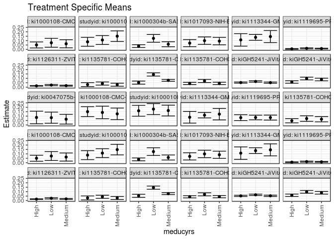

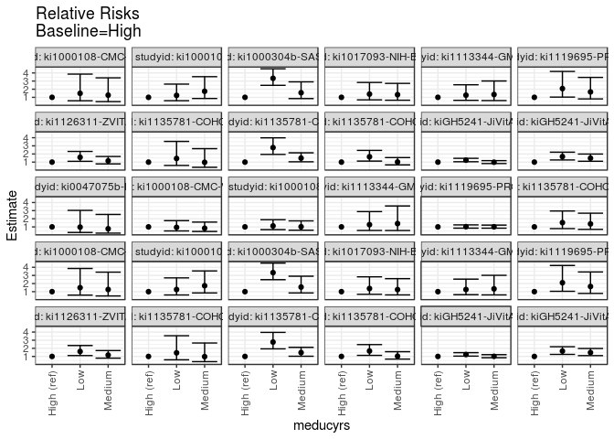

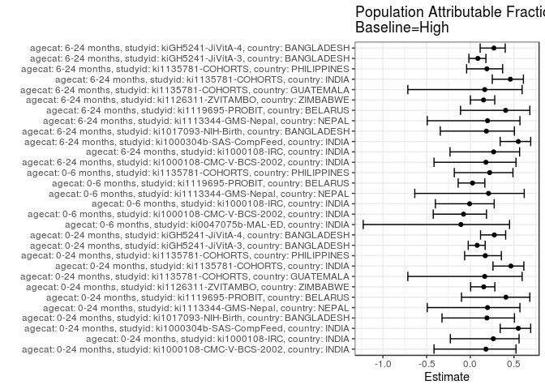

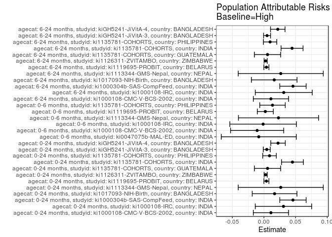

## Results Table

### Parameter: TSM

| agecat | studyid | country | intervention_level | baseline_level | estimate | ci_lower | ci_upper |
| --- | --- | --- | --- | --- | --- | --- | --- |
| 0-24 months | ki1000108-CMC-V-BCS-2002 | INDIA | High | NA | 0.0506329 | 0.0164006 | 0.0848652 |
| 0-24 months | ki1000108-CMC-V-BCS-2002 | INDIA | Low | NA | 0.0754717 | 0.0251181 | 0.1258253 |
| 0-24 months | ki1000108-CMC-V-BCS-2002 | INDIA | Medium | NA | 0.0642202 | 0.0181372 | 0.1103031 |
| 0-24 months | ki1000108-IRC | INDIA | High | NA | 0.0862347 | 0.0358462 | 0.1366232 |
| 0-24 months | ki1000108-IRC | INDIA | Low | NA | 0.1066792 | 0.0561937 | 0.1571647 |
| 0-24 months | ki1000108-IRC | INDIA | Medium | NA | 0.1501934 | 0.0898051 | 0.2105816 |
| 0-24 months | ki1000304b-SAS-CompFeed | INDIA | High | NA | 0.0375958 | 0.0215488 | 0.0536428 |
| 0-24 months | ki1000304b-SAS-CompFeed | INDIA | Low | NA | 0.1256370 | 0.0819409 | 0.1693331 |
| 0-24 months | ki1000304b-SAS-CompFeed | INDIA | Medium | NA | 0.0588288 | 0.0304520 | 0.0872055 |
| 0-24 months | ki1017093-NIH-Birth | BANGLADESH | High | NA | 0.0712106 | 0.0310302 | 0.1113909 |
| 0-24 months | ki1017093-NIH-Birth | BANGLADESH | Low | NA | 0.0994117 | 0.0573101 | 0.1415133 |
| 0-24 months | ki1017093-NIH-Birth | BANGLADESH | Medium | NA | 0.0942542 | 0.0522188 | 0.1362896 |
| 0-24 months | ki1113344-GMS-Nepal | NEPAL | High | NA | 0.1081081 | 0.0372999 | 0.1789163 |
| 0-24 months | ki1113344-GMS-Nepal | NEPAL | Low | NA | 0.1366906 | 0.1036918 | 0.1696895 |
| 0-24 months | ki1113344-GMS-Nepal | NEPAL | Medium | NA | 0.1456311 | 0.0774529 | 0.2138092 |
| 0-24 months | ki1119695-PROBIT | BELARUS | High | NA | 0.0056801 | 0.0013756 | 0.0099847 |
| 0-24 months | ki1119695-PROBIT | BELARUS | Low | NA | 0.0117934 | 0.0059001 | 0.0176868 |
| 0-24 months | ki1119695-PROBIT | BELARUS | Medium | NA | 0.0094588 | 0.0050526 | 0.0138650 |
| 0-24 months | ki1126311-ZVITAMBO | ZIMBABWE | High | NA | 0.0149423 | 0.0116354 | 0.0182492 |
| 0-24 months | ki1126311-ZVITAMBO | ZIMBABWE | Low | NA | 0.0238103 | 0.0166698 | 0.0309507 |
| 0-24 months | ki1126311-ZVITAMBO | ZIMBABWE | Medium | NA | 0.0171869 | 0.0117268 | 0.0226469 |
| 0-24 months | ki1135781-COHORTS | GUATEMALA | High | NA | 0.0287081 | 0.0060586 | 0.0513577 |
| 0-24 months | ki1135781-COHORTS | GUATEMALA | Low | NA | 0.0414938 | 0.0236814 | 0.0593061 |
| 0-24 months | ki1135781-COHORTS | GUATEMALA | Medium | NA | 0.0280899 | 0.0109180 | 0.0452618 |
| 0-24 months | ki1135781-COHORTS | INDIA | High | NA | 0.0518690 | 0.0344009 | 0.0693372 |
| 0-24 months | ki1135781-COHORTS | INDIA | Low | NA | 0.1444749 | 0.1264411 | 0.1625087 |
| 0-24 months | ki1135781-COHORTS | INDIA | Medium | NA | 0.0773732 | 0.0667263 | 0.0880200 |
| 0-24 months | ki1135781-COHORTS | PHILIPPINES | High | NA | 0.0424298 | 0.0298534 | 0.0550063 |
| 0-24 months | ki1135781-COHORTS | PHILIPPINES | Low | NA | 0.0703407 | 0.0528048 | 0.0878766 |
| 0-24 months | ki1135781-COHORTS | PHILIPPINES | Medium | NA | 0.0429874 | 0.0296533 | 0.0563216 |

[output cut: 60 more lines]

### Parameter: E(Y)

| agecat | studyid | country | intervention_level | baseline_level | estimate | ci_lower | ci_upper |
| --- | --- | --- | --- | --- | --- | --- | --- |
| 0-24 months | ki1000108-CMC-V-BCS-2002 | INDIA | NA | NA | 0.0616622 | 0.0372186 | 0.0861058 |
| 0-24 months | ki1000108-IRC | INDIA | NA | NA | 0.1170732 | 0.0859146 | 0.1482317 |
| 0-24 months | ki1000304b-SAS-CompFeed | INDIA | NA | NA | 0.0834553 | 0.0601989 | 0.1067118 |
| 0-24 months | ki1017093-NIH-Birth | BANGLADESH | NA | NA | 0.0880150 | 0.0639627 | 0.1120673 |
| 0-24 months | ki1113344-GMS-Nepal | NEPAL | NA | NA | 0.1346801 | 0.1072037 | 0.1621566 |
| 0-24 months | ki1119695-PROBIT | BELARUS | NA | NA | 0.0095893 | 0.0052864 | 0.0138922 |
| 0-24 months | ki1126311-ZVITAMBO | ZIMBABWE | NA | NA | 0.0176600 | 0.0150131 | 0.0203070 |
| 0-24 months | ki1135781-COHORTS | GUATEMALA | NA | NA | 0.0343840 | 0.0233416 | 0.0454263 |
| 0-24 months | ki1135781-COHORTS | INDIA | NA | NA | 0.0969241 | 0.0882972 | 0.1055510 |
| 0-24 months | ki1135781-COHORTS | PHILIPPINES | NA | NA | 0.0512273 | 0.0430760 | 0.0593786 |
| 0-24 months | kiGH5241-JiVitA-3 | BANGLADESH | NA | NA | 0.0568153 | 0.0526983 | 0.0609323 |
| 0-24 months | kiGH5241-JiVitA-4 | BANGLADESH | NA | NA | 0.0808042 | 0.0721841 | 0.0894244 |
| 0-6 months | ki0047075b-MAL-ED | INDIA | NA | NA | 0.0765550 | 0.0404216 | 0.1126884 |
| 0-6 months | ki1000108-CMC-V-BCS-2002 | INDIA | NA | NA | 0.1396648 | 0.1037072 | 0.1756225 |
| 0-6 months | ki1000108-IRC | INDIA | NA | NA | 0.1592040 | 0.1233945 | 0.1950135 |
| 0-6 months | ki1113344-GMS-Nepal | NEPAL | NA | NA | 0.1099291 | 0.0840909 | 0.1357673 |
| 0-6 months | ki1119695-PROBIT | BELARUS | NA | NA | 0.0846069 | 0.0570929 | 0.1121208 |
| 0-6 months | ki1135781-COHORTS | PHILIPPINES | NA | NA | 0.0609613 | 0.0448957 | 0.0770269 |
| 6-24 months | ki1000108-CMC-V-BCS-2002 | INDIA | NA | NA | 0.0616622 | 0.0372186 | 0.0861058 |
| 6-24 months | ki1000108-IRC | INDIA | NA | NA | 0.1170732 | 0.0859146 | 0.1482317 |
| 6-24 months | ki1000304b-SAS-CompFeed | INDIA | NA | NA | 0.0834553 | 0.0601989 | 0.1067118 |
| 6-24 months | ki1017093-NIH-Birth | BANGLADESH | NA | NA | 0.0880150 | 0.0639627 | 0.1120673 |
| 6-24 months | ki1113344-GMS-Nepal | NEPAL | NA | NA | 0.1346801 | 0.1072037 | 0.1621566 |
| 6-24 months | ki1119695-PROBIT | BELARUS | NA | NA | 0.0095893 | 0.0052864 | 0.0138922 |
| 6-24 months | ki1126311-ZVITAMBO | ZIMBABWE | NA | NA | 0.0176600 | 0.0150131 | 0.0203070 |
| 6-24 months | ki1135781-COHORTS | GUATEMALA | NA | NA | 0.0343840 | 0.0233416 | 0.0454263 |
| 6-24 months | ki1135781-COHORTS | INDIA | NA | NA | 0.0969241 | 0.0882972 | 0.1055510 |
| 6-24 months | ki1135781-COHORTS | PHILIPPINES | NA | NA | 0.0512273 | 0.0430760 | 0.0593786 |
| 6-24 months | kiGH5241-JiVitA-3 | BANGLADESH | NA | NA | 0.0568153 | 0.0526983 | 0.0609323 |
| 6-24 months | kiGH5241-JiVitA-4 | BANGLADESH | NA | NA | 0.0808042 | 0.0721841 | 0.0894244 |

### Parameter: RR

| agecat | studyid | country | intervention_level | baseline_level | estimate | ci_lower | ci_upper |
| --- | --- | --- | --- | --- | --- | --- | --- |
| 0-24 months | ki1000108-CMC-V-BCS-2002 | INDIA | High | High | 1.0000000 | 1.0000000 | 1.000000 |
| 0-24 months | ki1000108-CMC-V-BCS-2002 | INDIA | Low | High | 1.4905660 | 0.5765449 | 3.853624 |
| 0-24 months | ki1000108-CMC-V-BCS-2002 | INDIA | Medium | High | 1.2683486 | 0.4732218 | 3.399481 |
| 0-24 months | ki1000108-IRC | INDIA | High | High | 1.0000000 | 1.0000000 | 1.000000 |
| 0-24 months | ki1000108-IRC | INDIA | Low | High | 1.2370795 | 0.5830670 | 2.624683 |
| 0-24 months | ki1000108-IRC | INDIA | Medium | High | 1.7416811 | 0.8563183 | 3.542436 |
| 0-24 months | ki1000304b-SAS-CompFeed | INDIA | High | High | 1.0000000 | 1.0000000 | 1.000000 |
| 0-24 months | ki1000304b-SAS-CompFeed | INDIA | Low | High | 3.3417837 | 2.4756821 | 4.510885 |
| 0-24 months | ki1000304b-SAS-CompFeed | INDIA | Medium | High | 1.5647706 | 0.8438352 | 2.901641 |
| 0-24 months | ki1017093-NIH-Birth | BANGLADESH | High | High | 1.0000000 | 1.0000000 | 1.000000 |
| 0-24 months | ki1017093-NIH-Birth | BANGLADESH | Low | High | 1.3960248 | 0.6891714 | 2.827867 |
| 0-24 months | ki1017093-NIH-Birth | BANGLADESH | Medium | High | 1.3235983 | 0.6447334 | 2.717266 |
| 0-24 months | ki1113344-GMS-Nepal | NEPAL | High | High | 1.0000000 | 1.0000000 | 1.000000 |
| 0-24 months | ki1113344-GMS-Nepal | NEPAL | Low | High | 1.2643885 | 0.6291027 | 2.541204 |
| 0-24 months | ki1113344-GMS-Nepal | NEPAL | Medium | High | 1.3470874 | 0.6022147 | 3.013285 |
| 0-24 months | ki1119695-PROBIT | BELARUS | High | High | 1.0000000 | 1.0000000 | 1.000000 |
| 0-24 months | ki1119695-PROBIT | BELARUS | Low | High | 2.0762655 | 1.0293644 | 4.187903 |
| 0-24 months | ki1119695-PROBIT | BELARUS | Medium | High | 1.6652459 | 0.8031041 | 3.452907 |
| 0-24 months | ki1126311-ZVITAMBO | ZIMBABWE | High | High | 1.0000000 | 1.0000000 | 1.000000 |
| 0-24 months | ki1126311-ZVITAMBO | ZIMBABWE | Low | High | 1.5934784 | 1.0977555 | 2.313059 |
| 0-24 months | ki1126311-ZVITAMBO | ZIMBABWE | Medium | High | 1.1502152 | 0.7809756 | 1.694029 |
| 0-24 months | ki1135781-COHORTS | GUATEMALA | High | High | 1.0000000 | 1.0000000 | 1.000000 |
| 0-24 months | ki1135781-COHORTS | GUATEMALA | Low | High | 1.4453665 | 0.5887096 | 3.548582 |
| 0-24 months | ki1135781-COHORTS | GUATEMALA | Medium | High | 0.9784644 | 0.3606476 | 2.654648 |
| 0-24 months | ki1135781-COHORTS | INDIA | High | High | 1.0000000 | 1.0000000 | 1.000000 |
| 0-24 months | ki1135781-COHORTS | INDIA | Low | High | 2.7853783 | 1.9454441 | 3.987949 |
| 0-24 months | ki1135781-COHORTS | INDIA | Medium | High | 1.4917024 | 1.0371204 | 2.145533 |
| 0-24 months | ki1135781-COHORTS | PHILIPPINES | High | High | 1.0000000 | 1.0000000 | 1.000000 |
| 0-24 months | ki1135781-COHORTS | PHILIPPINES | Low | High | 1.6578119 | 1.1256592 | 2.441538 |
| 0-24 months | ki1135781-COHORTS | PHILIPPINES | Medium | High | 1.0131413 | 0.6598878 | 1.555500 |

[output cut: 60 more lines]

### Parameter: PAR

| agecat | studyid | country | intervention_level | baseline_level | estimate | ci_lower | ci_upper |
| --- | --- | --- | --- | --- | --- | --- | --- |
| 0-24 months | ki1000108-CMC-V-BCS-2002 | INDIA | High | NA | 0.0110293 | -0.0168377 | 0.0388962 |
| 0-24 months | ki1000108-IRC | INDIA | High | NA | 0.0308385 | -0.0137610 | 0.0754379 |
| 0-24 months | ki1000304b-SAS-CompFeed | INDIA | High | NA | 0.0458596 | 0.0250560 | 0.0666631 |
| 0-24 months | ki1017093-NIH-Birth | BANGLADESH | High | NA | 0.0168044 | -0.0185555 | 0.0521643 |
| 0-24 months | ki1113344-GMS-Nepal | NEPAL | High | NA | 0.0265720 | -0.0406554 | 0.0937994 |
| 0-24 months | ki1119695-PROBIT | BELARUS | High | NA | 0.0039092 | -0.0000537 | 0.0078720 |
| 0-24 months | ki1126311-ZVITAMBO | ZIMBABWE | High | NA | 0.0027177 | 0.0002496 | 0.0051858 |
| 0-24 months | ki1135781-COHORTS | GUATEMALA | High | NA | 0.0056758 | -0.0150637 | 0.0264153 |
| 0-24 months | ki1135781-COHORTS | INDIA | High | NA | 0.0450551 | 0.0277825 | 0.0623277 |
| 0-24 months | ki1135781-COHORTS | PHILIPPINES | High | NA | 0.0087975 | -0.0019555 | 0.0195504 |
| 0-24 months | kiGH5241-JiVitA-3 | BANGLADESH | High | NA | 0.0044540 | -0.0010340 | 0.0099421 |
| 0-24 months | kiGH5241-JiVitA-4 | BANGLADESH | High | NA | 0.0222428 | 0.0107535 | 0.0337320 |
| 0-6 months | ki0047075b-MAL-ED | INDIA | High | NA | -0.0081907 | -0.0674787 | 0.0510972 |
| 0-6 months | ki1000108-CMC-V-BCS-2002 | INDIA | High | NA | -0.0107528 | -0.0527961 | 0.0312905 |
| 0-6 months | ki1000108-IRC | INDIA | High | NA | -0.0012925 | -0.0539279 | 0.0513429 |
| 0-6 months | ki1113344-GMS-Nepal | NEPAL | High | NA | 0.0229725 | -0.0403694 | 0.0863144 |
| 0-6 months | ki1119695-PROBIT | BELARUS | High | NA | 0.0021667 | -0.0104835 | 0.0148170 |
| 0-6 months | ki1135781-COHORTS | PHILIPPINES | High | NA | 0.0135327 | -0.0066140 | 0.0336794 |
| 6-24 months | ki1000108-CMC-V-BCS-2002 | INDIA | High | NA | 0.0110293 | -0.0168377 | 0.0388962 |
| 6-24 months | ki1000108-IRC | INDIA | High | NA | 0.0313083 | -0.0137205 | 0.0763370 |
| 6-24 months | ki1000304b-SAS-CompFeed | INDIA | High | NA | 0.0458596 | 0.0250560 | 0.0666631 |
| 6-24 months | ki1017093-NIH-Birth | BANGLADESH | High | NA | 0.0162213 | -0.0198373 | 0.0522798 |
| 6-24 months | ki1113344-GMS-Nepal | NEPAL | High | NA | 0.0265720 | -0.0406554 | 0.0937994 |
| 6-24 months | ki1119695-PROBIT | BELARUS | High | NA | 0.0038822 | -0.0001216 | 0.0078860 |
| 6-24 months | ki1126311-ZVITAMBO | ZIMBABWE | High | NA | 0.0026836 | 0.0002028 | 0.0051644 |
| 6-24 months | ki1135781-COHORTS | GUATEMALA | High | NA | 0.0056758 | -0.0150637 | 0.0264153 |
| 6-24 months | ki1135781-COHORTS | INDIA | High | NA | 0.0444331 | 0.0270383 | 0.0618278 |
| 6-24 months | ki1135781-COHORTS | PHILIPPINES | High | NA | 0.0097259 | -0.0008334 | 0.0202852 |
| 6-24 months | kiGH5241-JiVitA-3 | BANGLADESH | High | NA | 0.0049229 | -0.0005942 | 0.0104401 |
| 6-24 months | kiGH5241-JiVitA-4 | BANGLADESH | High | NA | 0.0218526 | 0.0104009 | 0.0333043 |

### Parameter: PAF

| agecat | studyid | country | intervention_level | baseline_level | estimate | ci_lower | ci_upper |
| --- | --- | --- | --- | --- | --- | --- | --- |
| 0-24 months | ki1000108-CMC-V-BCS-2002 | INDIA | High | NA | 0.1788663 | -0.4151376 | 0.5235371 |
| 0-24 months | ki1000108-IRC | INDIA | High | NA | 0.2634119 | -0.2284719 | 0.5583440 |
| 0-24 months | ki1000304b-SAS-CompFeed | INDIA | High | NA | 0.5495101 | 0.3421911 | 0.6914892 |
| 0-24 months | ki1017093-NIH-Birth | BANGLADESH | High | NA | 0.1909267 | -0.3240990 | 0.5056264 |
| 0-24 months | ki1113344-GMS-Nepal | NEPAL | High | NA | 0.1972973 | -0.4926666 | 0.5683352 |
| 0-24 months | ki1119695-PROBIT | BELARUS | High | NA | 0.4076596 | -0.1006380 | 0.6812148 |
| 0-24 months | ki1126311-ZVITAMBO | ZIMBABWE | High | NA | 0.1538911 | 0.0041999 | 0.2810804 |
| 0-24 months | ki1135781-COHORTS | GUATEMALA | High | NA | 0.1650718 | -0.7149568 | 0.5935145 |
| 0-24 months | ki1135781-COHORTS | INDIA | High | NA | 0.4648490 | 0.2598375 | 0.6130761 |
| 0-24 months | ki1135781-COHORTS | PHILIPPINES | High | NA | 0.1717340 | -0.0646497 | 0.3556335 |
| 0-24 months | kiGH5241-JiVitA-3 | BANGLADESH | High | NA | 0.0783951 | -0.0236404 | 0.1702598 |
| 0-24 months | kiGH5241-JiVitA-4 | BANGLADESH | High | NA | 0.2752672 | 0.1172797 | 0.4049783 |
| 0-6 months | ki0047075b-MAL-ED | INDIA | High | NA | -0.1069915 | -1.2256042 | 0.4493944 |
| 0-6 months | ki1000108-CMC-V-BCS-2002 | INDIA | High | NA | -0.0769902 | -0.4238625 | 0.1853793 |
| 0-6 months | ki1000108-IRC | INDIA | High | NA | -0.0081185 | -0.3995603 | 0.2738413 |
| 0-6 months | ki1113344-GMS-Nepal | NEPAL | High | NA | 0.2089760 | -0.6353748 | 0.6173850 |
| 0-6 months | ki1119695-PROBIT | BELARUS | High | NA | 0.0256092 | -0.1390309 | 0.1664516 |
| 0-6 months | ki1135781-COHORTS | PHILIPPINES | High | NA | 0.2219883 | -0.1829896 | 0.4883283 |
| 6-24 months | ki1000108-CMC-V-BCS-2002 | INDIA | High | NA | 0.1788663 | -0.4151376 | 0.5235371 |
| 6-24 months | ki1000108-IRC | INDIA | High | NA | 0.2674247 | -0.2320749 | 0.5644204 |
| 6-24 months | ki1000304b-SAS-CompFeed | INDIA | High | NA | 0.5495101 | 0.3421911 | 0.6914892 |
| 6-24 months | ki1017093-NIH-Birth | BANGLADESH | High | NA | 0.1843011 | -0.3435504 | 0.5047713 |
| 6-24 months | ki1113344-GMS-Nepal | NEPAL | High | NA | 0.1972973 | -0.4926666 | 0.5683352 |
| 6-24 months | ki1119695-PROBIT | BELARUS | High | NA | 0.4048494 | -0.1118034 | 0.6814147 |
| 6-24 months | ki1126311-ZVITAMBO | ZIMBABWE | High | NA | 0.1519606 | 0.0013742 | 0.2798396 |
| 6-24 months | ki1135781-COHORTS | GUATEMALA | High | NA | 0.1650718 | -0.7149568 | 0.5935145 |
| 6-24 months | ki1135781-COHORTS | INDIA | High | NA | 0.4584315 | 0.2518926 | 0.6079487 |
| 6-24 months | ki1135781-COHORTS | PHILIPPINES | High | NA | 0.1898580 | -0.0419752 | 0.3701096 |
| 6-24 months | kiGH5241-JiVitA-3 | BANGLADESH | High | NA | 0.0866476 | -0.0161106 | 0.1790140 |
| 6-24 months | kiGH5241-JiVitA-4 | BANGLADESH | High | NA | 0.2704388 | 0.1130047 | 0.3999297 |